# Practical Machine Learning Course Project

## Overview

Using devices such as Jawbone Up, Nike FuelBand, and Fitbit it is now possible to collect a large amount of data about personal activity relatively inexpensively. These type of devices are part of the quantified self movement – a group of enthusiasts who take measurements about themselves regularly to improve their health, to find patterns in their behavior, or because they are tech geeks. One thing that people regularly do is quantify how much of a particular activity they do, but they rarely quantify how well they do it. In this project, your goal will be to use data from accelerometers on the belt, forearm, arm, and dumbell of 6 participants. They were asked to perform barbell lifts correctly and incorrectly in 5 different ways.

The goal of this project is to predict the manner in which they did the exercise.

## Data Pre-processing

```r
#loading libraries
library(ggplot2)
library(caret)
library(RColorBrewer)
library(rattle)
library(randomForest)
library(corrplot)
library(lattice)
library(kernlab)
```

## Data exploration

```r
# reading in data
training_csv <- read.csv("pml-training.csv")
testing_csv <- read.csv("pml-testing.csv")
head(training_csv)
```

|  | X | user_name | raw_timestamp_part_1 | raw_timestamp_part_2 | cvtd_timestamp | new_window | num_window | roll_belt | pitch_belt | yaw_belt | total_accel_belt | kurtosis_roll_belt | kurtosis_picth_belt | kurtosis_yaw_belt | skewness_roll_belt | skewness_roll_belt.1 | skewness_yaw_belt | max_roll_belt | max_picth_belt | max_yaw_belt | min_roll_belt | min_pitch_belt | min_yaw_belt | amplitude_roll_belt | amplitude_pitch_belt | amplitude_yaw_belt | var_total_accel_belt | avg_roll_belt | stddev_roll_belt | … |
| --- | --- | --- | --- | --- | --- | --- | --- | --- | --- | --- | --- | --- | --- | --- | --- | --- | --- | --- | --- | --- | --- | --- | --- | --- | --- | --- | --- | --- | --- | --- |
| 1 | 1 | carlitos | 1323084231 | 788290 | 05/12/2011 11:23 | no | 11 | 1.41 | 8.07 | -94.4 | 3 |  |  |  |  |  |  | NA | NA |  | NA | NA |  | NA | NA |  | NA | NA | NA | … |
| 2 | 2 | carlitos | 1323084231 | 808298 | 05/12/2011 11:23 | no | 11 | 1.41 | 8.07 | -94.4 | 3 |  |  |  |  |  |  | NA | NA |  | NA | NA |  | NA | NA |  | NA | NA | NA | … |
| 3 | 3 | carlitos | 1323084231 | 820366 | 05/12/2011 11:23 | no | 11 | 1.42 | 8.07 | -94.4 | 3 |  |  |  |  |  |  | NA | NA |  | NA | NA |  | NA | NA |  | NA | NA | NA | … |
| 4 | 4 | carlitos | 1323084232 | 120339 | 05/12/2011 11:23 | no | 12 | 1.48 | 8.05 | -94.4 | 3 |  |  |  |  |  |  | NA | NA |  | NA | NA |  | NA | NA |  | NA | NA | NA | … |
| 5 | 5 | carlitos | 1323084232 | 196328 | 05/12/2011 11:23 | no | 12 | 1.48 | 8.07 | -94.4 | 3 |  |  |  |  |  |  | NA | NA |  | NA | NA |  | NA | NA |  | NA | NA | NA | … |
| 6 | 6 | carlitos | 1323084232 | 304277 | 05/12/2011 11:23 | no | 12 | 1.45 | 8.06 | -94.4 | 3 |  |  |  |  |  |  | NA | NA |  | NA | NA |  | NA | NA |  | NA | NA | NA | … |

```r
# viewing dimensions of datasets
dim(training_csv)
```

```
## [1] 19622   160
```

```r
dim(testing_csv)
```

```
## [1]  20 160
```

```r
# removing missing values
training_csv <- training_csv[,colMeans(is.na(training_csv)) == 0]
# removing irrelevant variables
training_csv <- training_csv[,-c(1:7)]
dim(training_csv)
```

```
## [1] 19622    86
```

Having cleaned the data, we must now split the training dataset into a sub-training dataset and a testing dataset.

```r
set.seed(1000)
subTrain <- createDataPartition(training_csv$classe, p=0.7, list=F)
train_data <- training_csv[subTrain, ]
test_data <- training_csv[-subTrain, ]

# removing near-zero variance variables
nzv <- nearZeroVar(train_data)
train_data <- train_data[,-nzv]
test_data <- test_data[,-nzv]

dim(train_data)
```

```
## [1] 13737    53
```

```r
dim(test_data)
```

```
## [1] 5885   53
```

## Building and testing the models

The three models we will use are random forests, generalised boosted regression model, and decision tree classification. First, we establish a control:

```r
control_data <- trainControl(method="cv", number=3, verboseIter=F)
```

### Random Forests

```r
rf_model <- train(classe~., data=train_data, method="rf", trControl=control_data)
predict_rf <- predict(rf_model, test_data)
conmatrf <- confusionMatrix(predict_rf, factor(test_data$classe))

conmatrf
```

```
## Confusion Matrix and Statistics
##
##           Reference
## Prediction    A    B    C    D    E
##          A 1672    9    0    0    0
##          B    2 1125    4    1    0
##          C    0    5 1020    8    0
##          D    0    0    2  951    2
##          E    0    0    0    4 1080
##
## Overall Statistics
##
##                Accuracy : 0.9937
##                  95% CI : (0.9913, 0.9956)
##     No Information Rate : 0.2845
##     P-Value [Acc > NIR] : < 2.2e-16
##
##                   Kappa : 0.992
##
##  Mcnemar's Test P-Value : NA
##
## Statistics by Class:
##
##                      Class: A Class: B Class: C Class: D Class: E
## Sensitivity            0.9988   0.9877   0.9942   0.9865   0.9982
## Specificity            0.9979   0.9985   0.9973   0.9992   0.9992
## Pos Pred Value         0.9946   0.9938   0.9874   0.9958   0.9963
## Neg Pred Value         0.9995   0.9971   0.9988   0.9974   0.9996
## Prevalence             0.2845   0.1935   0.1743   0.1638   0.1839
## Detection Rate         0.2841   0.1912   0.1733   0.1616   0.1835
## Detection Prevalence   0.2856   0.1924   0.1755   0.1623   0.1842
## Balanced Accuracy      0.9983   0.9931   0.9957   0.9929   0.9987
```

```r
round(conmatrf$overall['Accuracy'],5)
```

```
## Accuracy
##  0.99371
```

The accuracy rate of the random forest is very high (0.99371), and the out of sample error rate is thus around 0.01.

Plotting the model:

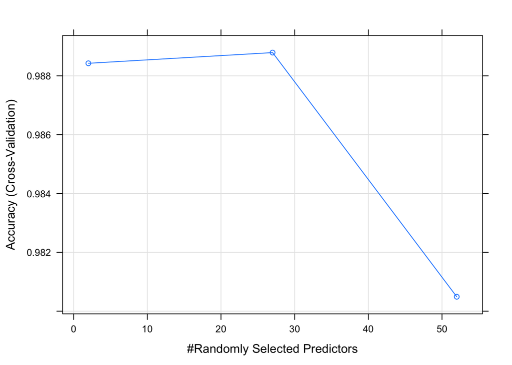

```r
plot(rf_model)
```

### Generalised Boosted regression model

```r
gbm_model <- train(classe~., data=train_data, method="gbm", trControl=control_data)
predict_gbm <- predict(gbm_model, test_data)
conmatgbm <- confusionMatrix(predict_gbm, factor(test_data$classe))
conmatgbm
```

```
## Confusion Matrix and Statistics
##
##           Reference
## Prediction    A    B    C    D    E
##          A 1647   47    0    4    1
##          B   21 1056   32    7   12
##          C    4   34  981   33    4
##          D    2    2   11  914   10
##          E    0    0    2    6 1055
##
## Overall Statistics
##
##                Accuracy : 0.9606
##                  95% CI : (0.9553, 0.9654)
##     No Information Rate : 0.2845
##     P-Value [Acc > NIR] : < 2.2e-16
##
##                   Kappa : 0.9501
##
##  Mcnemar's Test P-Value : 4.747e-06
##
## Statistics by Class:
##
##                      Class: A Class: B Class: C Class: D Class: E
## Sensitivity            0.9839   0.9271   0.9561   0.9481   0.9750
## Specificity            0.9877   0.9848   0.9846   0.9949   0.9983
## Pos Pred Value         0.9694   0.9362   0.9290   0.9734   0.9925
## Neg Pred Value         0.9935   0.9826   0.9907   0.9899   0.9944
## Prevalence             0.2845   0.1935   0.1743   0.1638   0.1839
## Detection Rate         0.2799   0.1794   0.1667   0.1553   0.1793
## Detection Prevalence   0.2887   0.1917   0.1794   0.1596   0.1806
## Balanced Accuracy      0.9858   0.9560   0.9704   0.9715   0.9867
```

```r
round(conmatgbm$overall['Accuracy'],5)
```

```
## Accuracy
##  0.96058
```

Plotting the model:

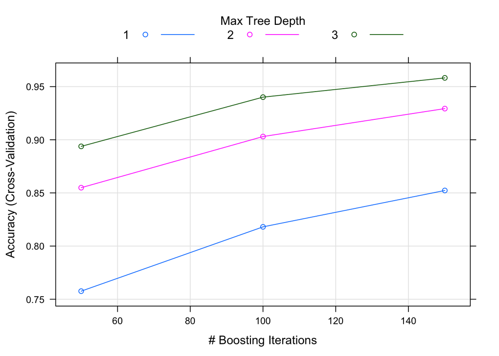

```r
plot(gbm_model)
```

### Decision Tree classification

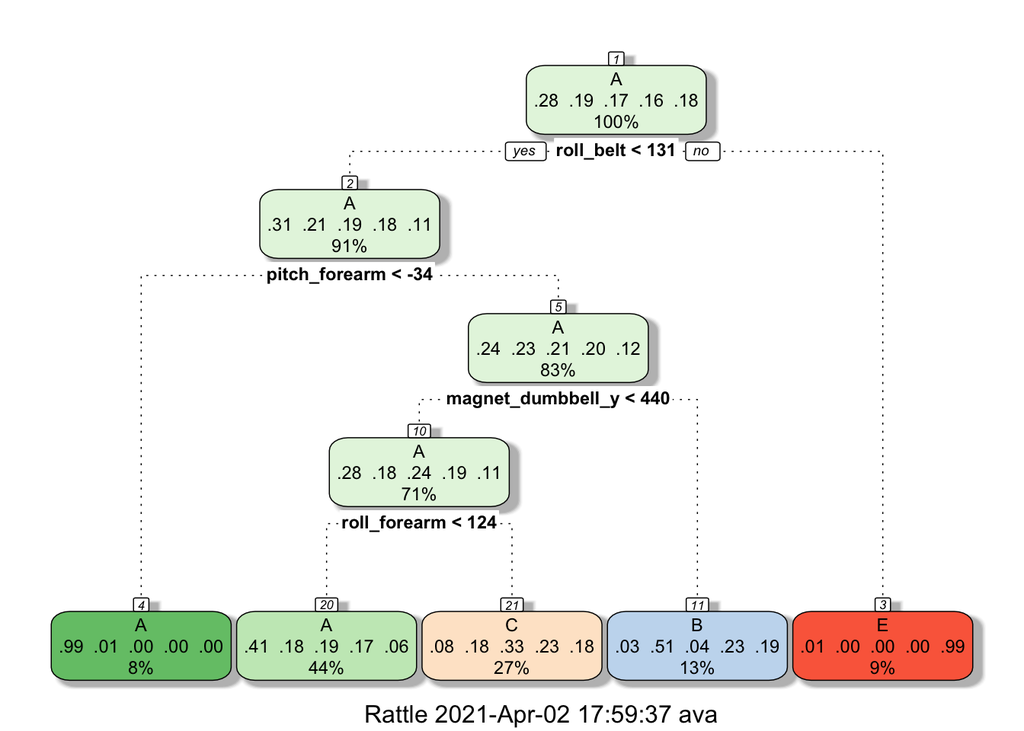

```r
dectree_model <- train(classe~., data=train_data, method="rpart", trControl=control_data)
fancyRpartPlot(dectree_model$finalModel)
```

```r
predict_dectree <- predict(dectree_model, test_data)
conmatdectree <- confusionMatrix(predict_dectree, factor(test_data$classe))
conmatdectree
```

```
## Confusion Matrix and Statistics
##
##           Reference
## Prediction    A    B    C    D    E
##          A 1523  487  474  445  173
##          B   27  396   34  165  154
##          C  121  256  518  354  291
##          D    0    0    0    0    0
##          E    3    0    0    0  464
##
## Overall Statistics
##
##                Accuracy : 0.4929
##                  95% CI : (0.4801, 0.5058)
##     No Information Rate : 0.2845
##     P-Value [Acc > NIR] : < 2.2e-16
##
##                   Kappa : 0.3366
##
##  Mcnemar's Test P-Value : NA
##
## Statistics by Class:
##
##                      Class: A Class: B Class: C Class: D Class: E
## Sensitivity            0.9098  0.34767  0.50487   0.0000  0.42884
## Specificity            0.6250  0.91993  0.78967   1.0000  0.99938
## Pos Pred Value         0.4910  0.51031  0.33636      NaN  0.99358
## Neg Pred Value         0.9457  0.85457  0.88308   0.8362  0.88594
## Prevalence             0.2845  0.19354  0.17434   0.1638  0.18386
## Detection Rate         0.2588  0.06729  0.08802   0.0000  0.07884
## Detection Prevalence   0.5271  0.13186  0.26168   0.0000  0.07935
## Balanced Accuracy      0.7674  0.63380  0.64727   0.5000  0.71411
```

```r
round(conmatdectree$overall['Accuracy'], 5)
```

```
## Accuracy
##  0.49295
```

This model has a very low accuracy of less than 0.5 (0.49295), certainly far less accurate than the previous two models we have trained. The out of sample error rate is around 0.5.

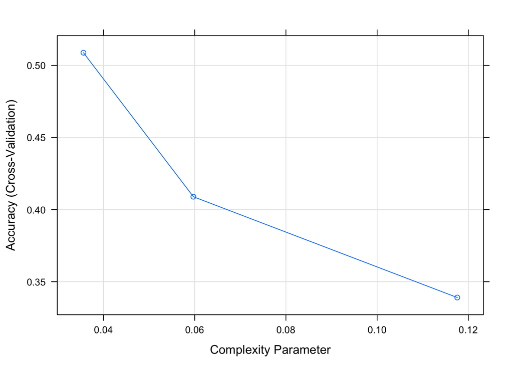

```r
plot(dectree_model)
```

## Application of best model

From the above, we can see that the best model is the random forest model, with 0.99371 accuracy and around 0.01 out of sample error rate. Therefore, this is the model we will use.

```r
predict <- predict(rf_model, testing_csv)
print(predict)
```

```
##  [1] B A B A A E D B A A B C B A E E A B B B
## Levels: A B C D E
```